# Statistical Inference II

Chelsea Parlett-Pelleriti

# Evaluating an Estimator

## Review: Estimands, Estimator, Estimates

- **Estimand**: a target quantity to be estimated
  - $\mu$ mean height of all people named Michael in the US
- **Estimator**: a function, $W(\mathbf{x})$ that is a *recipe* about how to get an estimate from a sample
  - $\bar{x} = W(\mathbf{heights}) = \frac{1}{N} \sum_{i=1}^N height_i$
- **Estimate**: a realized value of $W(\mathbf{x})$ applied to an actual sample, $\mathbf{x}$
  - $\bar{x} = W(176,177,175,179,173) = 176$

## Evaluating an Estimator

The goal of an estimator is to estimate the estimand *well*.  
This is important because it’s what allows us to make inferences about a **Population** statistic based on a **Sample** statistic. This is the core of inference. *Good* estimators will be:

- Unbiased
- Consistent
- Efficient

## Evaluating an Estimator: Unbiasedness

**Intuitive Idea**: our estimator, $\hat{\theta}$ should not consistently mis-estimate $\theta$ in a systematic way

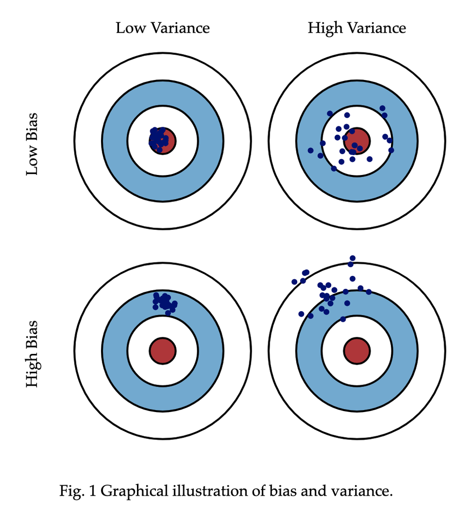

from Scott Fortmann-Roe

## Evaluating an Estimator: Unbiasedness

Math Idea: an estimator $\hat{\theta}$ is unbiased if

$$\mathbb{E}(\hat{\theta}) = \theta$$

## Evaluating an Estimator: Unbiasedness

### Sample Mean Estimator

$$\hat{\mu} = \frac{1}{n}\sum_{i=1}^{n}\mathbf{X}_i$$

$$\mathbb{E}[\hat{\mu}] = \mathbb{E} \left [ \frac{1}{n}\sum_{i=1}^{n}\mathbf{X}_i\right] = \frac{1}{n}\sum_{i=1}^{n}\mathbb{E} \left [ \mathbf{X}_i\right] = \mu$$

Thus, the sample mean, $\hat{\mu}$ is an *unbiased estimator* of the population mean $\mu$

Note we’re using $\hat{}$ in this section (pronounced “hat”) for consistency. Common estimators like the sample mean often have their own symbols like $\bar{x}$ which you’ll also see used. In general, putting a $\hat{}$ on something means that we’re creating an estimate of it.

## Evaluating an Estimator: Unbiasedness

- Population Variance = $\frac{1}{n}\sum(x_i-\mu)^2$
- Sample Variance = $\frac{1}{n}\sum(x_i-\bar{x})^2$

## Sample Variance

```r
# Function to demonstrate bias in sample variance estimation
demonstrate_variance_bias <- function(n = 10, true_mean = 0, true_var = 1, n_sims = 1000) {
  # Initialize vectors to store estimates
  var_biased <- numeric(n_sims)
  var_unbiased <- numeric(n_sims)

  # Run simulations
  for (i in 1:n_sims) {
    # Generate random normal data
    x <- rnorm(n, mean = true_mean, sd = sqrt(true_var))
    # Biased estimator: divide by n
    var_biased[i] <- sum((x - mean(x))^2) / n
    # Unbiased estimator: divide by n-1
    var_unbiased[i] <- sum((x - mean(x))^2) / (n-1)
  }
  return(data.frame(biased = var_biased, unbiased = var_unbiased))
}
```

## Sample Variance

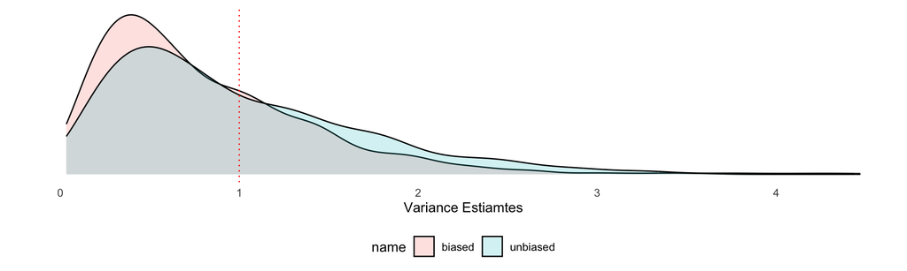

## Sample Variance

$$\hat{\sigma}^2 = \frac{1}{n} \sum_{i=1}^n \left( \mathbf{X}_i - \hat{\mu}\right)^2$$

$$\mathbb{E}[\hat{\sigma}^2] = \mathbb{E}\left[ \frac{1}{n} \sum_{i=1}^n \left( \mathbf{X}_i - \hat{\mu}\right)^2 \right] = \frac{n-1}{n}\sigma^2$$

Thus, the sample mean, $\hat{\sigma}^2$ is a *biased estimator* of the population variance $\sigma^2$

Note: this is why, when calculating the sample variance, we divide by $N-1$ instead of $N$. Intuitively this makes sense: when we estimate the sample mean $\hat{\mu}$, we’re losing 1 degree of freedom, then we use that estimate to estimate $\hat{\sigma}^2$…

## Evaluating an Estimator: Consistency

**Intuitive Idea**: as we collect more data (information) the estimator should approximate the estimand more closely.  
If we could have $\infty$ information, our estimator should spit out estimates equal to the estimand.

## Evaluating an Estimator: Consistency

**Math Idea**:

$$\lim_{n \to \infty} \hat{\theta} = \theta$$

**Example**:

Sample Mean: The Law of Large Numbers guarantees that:

$$\lim_{n \to \infty} \hat{\mu} = \mu$$

## Evaluating an Estimator: Consistency

### Weak Law of Large Numbers

**Intuitive Idea**: as you get more and more independent, random samples of $\mathbf{X}$, the sample mean of $\mathbf{X}$ will get closer and closer (and eventually converge) to it’s expected value.

**Math Idea**: for all $\epsilon > 0$, if $\sigma^2 < \infty$

$$\lim_{n \to \infty} P(|\bar{X_n} - \mu| < \epsilon) = 1$$

## Evaluating an Estimator: Consistency

### Weak Law of Large Numbers Proof

For a random variable $X$ with finite variance $\sigma^2$ and expected value $\mu$

$$P(|\bar{X_n} - \mu| \geq \epsilon) =
\frac{Var(\bar{X})}{\epsilon^2} = \frac{\sigma^2}{n\epsilon^2}$$

As $n \to \infty$, $\frac{\sigma^2}{n\epsilon^2} \to 0$. So the probability that $|\bar{X_n} - \mu| \geq \epsilon$ goes to $0$. Thus, $P(|\bar{X_n} - \mu| < \epsilon) \to 1$

Note: we’re using **Chebychev’s Inequality** here which states that $P(|X-\mu| \geq k) \leq \frac{\sigma^2}{k^2}$

## Evaluating an Estimator: Efficiency

**Intuitive Idea**: (for unbiased estimators*) the estimate we get should have the smallest variance possible (so that we can be more confident about our estimate with as little data as possible)

*Otherwise we could just always predict 42 and have a 0 variance estimator.

## Evaluating an Estimator: Efficiency

**Math Idea**:

$$Var(\hat{\theta}) \geq \frac{1}{I(\theta)}$$

where $I(\theta)$ is the Fisher Information for $\theta$

## Evaluating an Estimator: Efficiency

**Math Idea**:

$$Var(\hat{\theta}) \geq \frac{1}{I(\theta)}$$

$1/I(\theta)$ is the absolute minimum possible amount of toothpaste left in the tube. $Var(\hat{\theta})$ is how much toothpaste you actually left by your method (the estimator). An efficient estimator will leave very little ( close to $1/I(\theta)$) toothpaste. HOW MUCH TOOTHPASTE DOES YOUR METHOD LEAVE BEHIND??

## Evaluating an Estimator: Efficiency

### Fisher Information

**Intuitive Idea**: the amount of information that a sample from a random variable $\mathbf{X}$ can give us about a parameter $\theta$

- Imagine that everyone in Room A has the same number of cats ($\mu_A$)
- Imagine that cat ownership in Room B is defined as $Pois(\mu_B)$ where $\mu_B$ is the mean number of cats owned in Room B

In which Room do I learn more about $\mu$ by asking one person how many cats they own?

## Evaluating an Estimator: Efficiency

### Fisher Information

**Intuitive Idea**: the amount of information that a sample from a random variable $\mathbf{X}$ can give us about a parameter $\theta$

- Imagine that Room A has $\text{height}_{cm} \sim \mathcal{N}(\mu_A, 8)$
- Imagine that Room B has $\text{height}_{cm} \sim \mathcal{N}(\mu_B, 1)$

In which Room do I learn more about $\mu$ by asking one person their height?

## Evaluating an Estimator: Efficiency

### Fisher Information

**Slightly Mathy Idea**: Fisher Information measures how *sensitive* the log-likelihood function $\ell(\theta | X)$ is to changes in $\theta$ (more sensitive $\to$ more information)

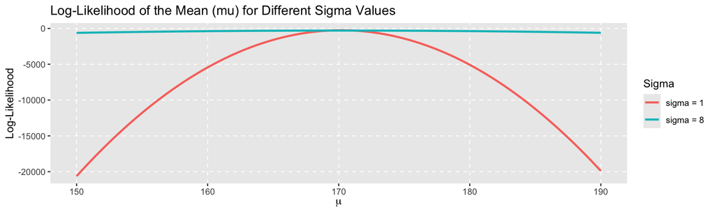

## Evaluating an Estimator: Efficiency

### Fisher Information

**Math Idea**:

$$I_X(\theta) = -\mathbb{E}\left[\frac{\partial^2 \ell(\theta | X)}{\partial\theta^2} \right]$$

where $\ell(\theta | X)$ is the log-likelihood of $\theta$ given $X$. If $\ell$ is sensitive to changes in $\theta$, the second derivative should be *large* and we expect to see *high* information

Note: usually $\ell$ is concave down around maximum likelihood estimate, meaning that the second-derivative will be negative, hence the negative sign in front of the expectation

## Evaluating an Estimator: Efficiency

Example: for a $\mathcal{N}(\mu,\sigma)$ distribution, both the sample **mean** and sample **median** are unbiased estimators of $\mu$, the population mean.

- sample mean variance: $\frac{\sigma^2}{n}$
- sample median variance (approx): $\frac{\pi}{2} \cdot \frac{\sigma^2}{n}$

the sample mean is more efficient than the median, the median needs 57% more data to get the same variance as the mean.

## Estimators Wrap-Up

- **Estimators** take in sample data and produce a sample **estimate**
- Good **estimators** produce **estimates** that allow us to make inferences about **population** parameters
  - Unbiased, Consistent, Efficient
- These estimates are (so far) **individual numbers** that are *guesses* for population parameters

## Point Estimates vs. Interval Estimates

- **Point Estimate**: a single value calculated based on a sample that estimates a population parameter
- **Interval Estimate**: a range of values calculated based on a sample that estimate a population parameter *with uncertainty (variance)*

E.g. the mean height of Michaels is **178cm** vs. the mean height of Michaels is between **175-181cm**

## Point Estimates vs. Interval Estimates

Think about the research or industry work you’ve done. When would interval estimates have been helpful?

## Point Estimates vs. Interval Estimates

Think about the research or industry work you’ve done. When would interval estimates have been helpful?

My Story: the clients who didn’t report uncertainty…

## Inference: Second Problem

In the last class, we talked about the first problem of inference: data is too complex to reason about, we need *summaries*. But now that we’ve exhaustively discussed the problem of point estimates, we run into the second problem of inference…

**Uncertainty**.

## Inference: Second Problem

Claim: My **mean** crossword time is faster than yours.

- my time: 25m 05s
- your time: 25m 23s

Is this 👆 enough to convince you that my mean time is faster than yours? Why/Why not?

## Inference: Second Problem

Pro: 🤷‍♀️ the sample mean is an unbiased estimate

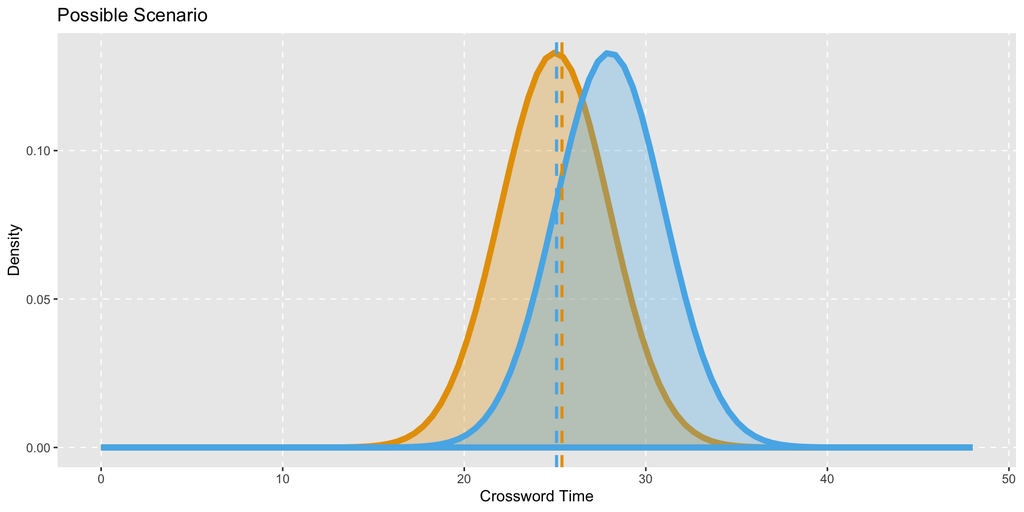

## Inference: Second Problem

First problem: we need some more data…

```r
set.seed(540)
n <- 1000
# generate fake crossword data
me <- rnorm(n, mean = 25, sd = 3)
you <- rnorm(n, mean = 28, sd = 3)

 df <- data.frame(source = sort(rep(c("me", "you"),n)),
                 scores = c(me,you))
```

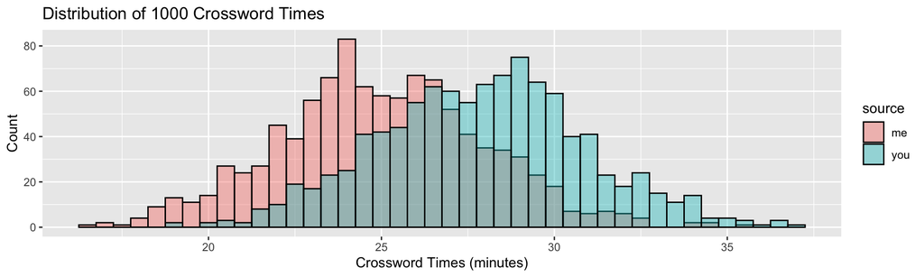

Now that we have more data, Is this 👆 enough to convince you that my mean time is faster than yours? Why/Why not?

# Quantifying Uncertainty

## **Frequentist** Statistics

**Frequentism** main Ideas:

1. data ($X$) is a **random** sample of our process $P_{\theta}$, the parameters ($\theta$) are **fixed**
   - we imagine different *samples* that could exist
2. inference relies on the idea of **repeated samples of** $X$ from $P_{\theta}$
3. probabilities are the *long run* **frequen**cy of an event

$$p = \lim_{n \to \infty} \frac{k}{n}$$

## Bayesian Statistics

**Bayesianism** main Ideas:

1. data $X$ is **fixed**, and the parameters $\theta$ of our process $P_{\theta}$ are **random**
   - we imagine different *parameter values* that could exist
2. inference relies on the idea of **updating prior beliefs** based on evidence from the data
3. probabilities are used to **quantify uncertainty** we have about parameters

$$\underbrace{p(\theta|d)}_\text{posterior} = \underbrace{\frac{p(d|\theta)}{p(d)}}_\text{update} \times \underbrace{p(\theta)}_\text{prior}$$

## Bayesian vs. Frequentist Probability

In the past month, it’s rained on 9 of the 30 days. 🌧️

- **Frequentist**: the probability of rain is $q = \frac{9}{30} = 0.3$
- **Bayesian**: before seeing the data, values of $q$ near $0.1$ sounded the most reasonable based on my knowledge of California. After seeing the data, I think the probability of rain $q$ is most likely $0.25$ but there’s a lot of uncertainty.

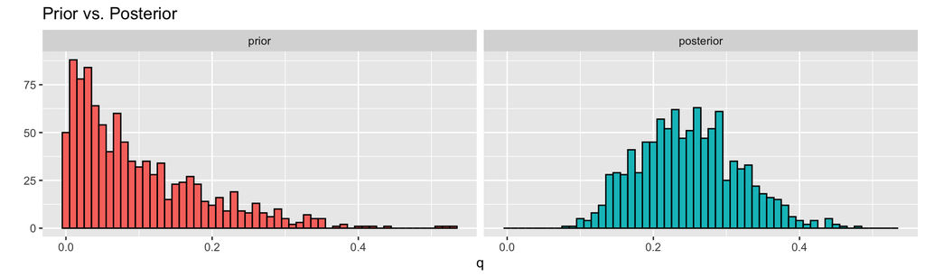

## Frequentist Uncertainty

In a frequentist analysis, **uncertainty** represents **sampling variability**: the difference between estimates on repeated, similar samples.  
💡 *if i took a bunch of random samples exactly like this one, how variable would my **estimates** be?*

## Frequentist Uncertainty

If I take repeated random samples of 2 people from my list of **J**’s, what are the different mean ages that I get?

(*hint*: `sample(c(17,24,21,19,25,28,23,20,23,25), size = 2, replace = TRUE))`)

| idx | Name | Age |
| --- | --- | --- |
| 1 | John | 17 |
| 2 | James | 24 |
| 3 | Jane | 21 |
| 4 | June | 19 |
| 5 | Joachim | 25 |
| 6 | Jess | 28 |
| 7 | Javier | 23 |
| 8 | Jaques | 20 |
| 9 | Julie | 23 |
| 10 | Jackson | 25 |

## Frequentist Uncertainty

If I take repeated random samples of 8 people from my list of **J**’s, what are the different mean ages that I get?

(*hint*: `sample(c(17,24,21,19,25,28,23,20,23,25), size = 8, replace = TRUE))`)

| idx | Name | Age |
| --- | --- | --- |
| 1 | John | 17 |
| 2 | James | 24 |
| 3 | Jane | 21 |
| 4 | June | 19 |
| 5 | Joachim | 25 |
| 6 | Jess | 28 |
| 7 | Javier | 23 |
| 8 | Jaques | 20 |
| 9 | Julie | 23 |
| 10 | Jackson | 25 |

## Frequentist Uncertainty

Remember, our sample mean $\bar{x}$ is our estimate of our population mean $\mu$. In which case are the sample means we get most *certain*?

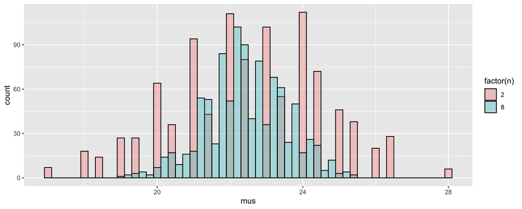

## Frequentist Uncertainty

Let’s say income of Chapman workers is $\text{income} \sim gamma(0.6, 100000)$

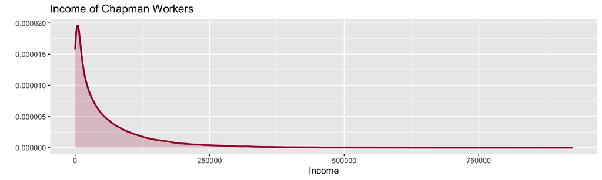

❓if I sample 2 people, how likely is it that I’ll get a sample mean near $500,000

❓if I sample 2,000 people, how likely is it that I’ll get a sample mean near $500,000

## Frequentist Uncertainty

1. The more data we have, the more **certain** we are about our estimates
2. The more data we have, the less likely we are to get *all* **extreme** values

## Sampling Distributions

**Sampling Distribution**: the theoretical distribution of all possible **estimates** that result from taking a sample of size $n$ from $P_{\theta}$

e.g. Sampling Distribution of $\bar{x}$ , Sampling Distribution of $\sigma$, Sampling Distribution of $q$

## Sampling Distributions: Example

### Sampling Distribution of $q$

```r
coin_flips <- sample(0:1, size = 100, replace = TRUE) # heads = 1
mean(coin_flips) # proportion of heads
```

```
[1] 0.53
```

Everyone run this code 10 times, and put the proportions of heads in [this sheet](https://docs.google.com/spreadsheets/d/1_Xq0gLtEJAyhaN5O_skIdnxoce2zC7O21tpx6bEpkow/edit?usp=sharing).

## Sampling Distributions: Example

### Sampling Distribution of $q$

How much uncertainty do we have about $\hat{q}$?

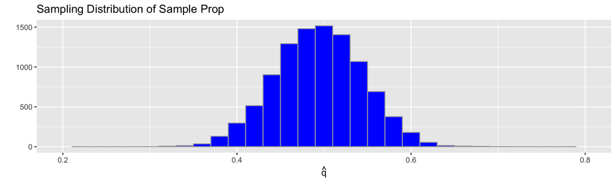

## Sampling Distributions: Example

### Sampling Distribution of $q$

- What is the **range** of $\hat{q}$s that cover 90% of samples?
- What is our **best guess** for what $\hat{q}$ is?

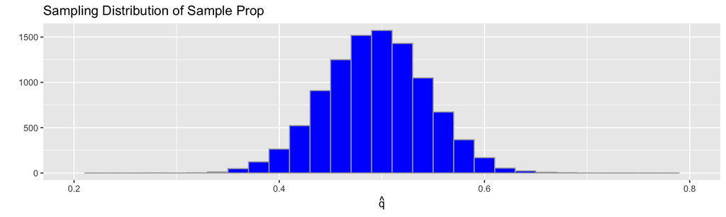

## Sampling Distributions: Example

### Sampling Distribution of $q$

- What is the **range** of $\hat{q}$s that cover 90% of samples?

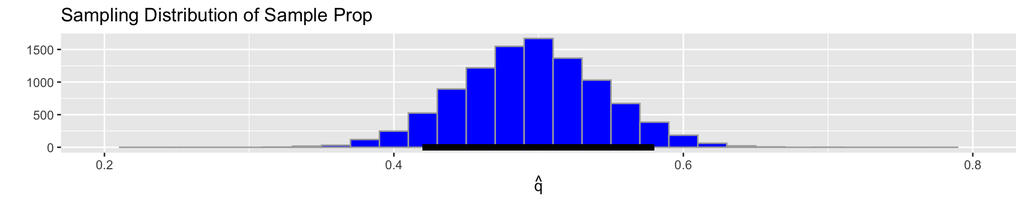

```r
# simulated sampling dist
coin_flips <- replicate(10000, mean(sample(0:1, size = 100, replace = TRUE)))

# calculate 5th and 95th percentile
ci <- quantile(coin_flips, c(0.05,0.95))
# plot
ggplot(data = data.frame(x = coin_flips),
       aes(x = x)) + geom_histogram(binwidth = 0.02, fill = "blue", color = "darkgray") +
  xlim(c(0.2,0.8)) +
  geom_segment(x = ci[[1]],
               xend = ci[[2]],
               y = -1,
               yend = -1,
               linewidth = 2) +
  labs(x = expression(hat(q)),
       y = "",
       title = "Sampling Distribution of Sample Prop")
```

## Sampling Distributions: Example

### Sampling Distribution of $q$

- What is our **best guess** for what $\hat{q}$ is?

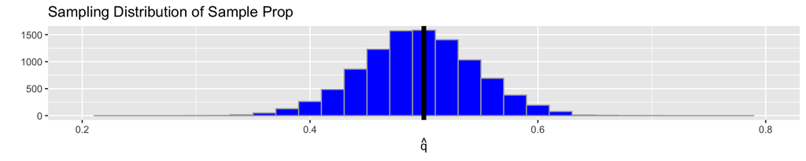

```r
# simulated sampling dist
coin_flips <- replicate(10000, mean(sample(0:1, size = 100, replace = TRUE)))

# calculate mean
mu <- mean(coin_flips)

# plot
ggplot(data = data.frame(x = coin_flips),
       aes(x = x)) + geom_histogram(binwidth = 0.02, fill = "blue", color = "darkgray") +
  xlim(c(0.2,0.8)) +
  geom_vline(xintercept = mu,
             linewidth = 2) +
  labs(x = expression(hat(q)),
       y = "",
       title = "Sampling Distribution of Sample Prop")
```

## Sampling Distribution: Analytical

So far, we used **Monte Carlo** simulations to approximate the sampling distribution. But, often we can *directly calculate it* instead.  
**Claim**: Sampling Distributions of sample means will (*often*) be a Normal Distribution, and we can use what we know about Normal Distributions to calculate our **point estimate** (best guess) and our **interval estimates** (uncertainty).

## Review: LLN

For a random variable $X$ with finite variance $\sigma^2$ and expected value $\mu$

$$P(|\bar{X_n} - \mu| \geq \epsilon) =
\frac{Var(\bar{X})}{\epsilon^2} = \frac{\sigma^2}{n\epsilon^2}$$

As $n \to \infty$, $\frac{\sigma^2}{n\epsilon^2} \to 0$. So the probability that $|\bar{X_n} - \mu| \geq \epsilon$ goes to $0$. Thus, $P(|\bar{X_n} - \mu| < \epsilon) \to 1$

💡 In other words, $\bar{X}_n \to \mu$, as $n \to \infty$. The larger our sample, the more concentrated the sampling distribution will be around $\mu$

## Central Limit Theorem

Note: this is the **Central**, Limit-Theorem:

Let $\mathbf{X}$ be a random variable with finite variance $\sigma^2$. As $n \to \infty$, the distribution of sample means will be distributed as a normal distribution:

$$\bar{x} \sim \mathcal{N}\left( \mu, \frac{\sigma^2}{n}\right)$$

## Central Limit Theorem

Why is this useful?

- we know a lot about the normal distribution, no more simulating to find out the point/interval estimate, we can calculate it directly!
- even if the population data is **not** normally-distributed, the sampling distribution of $\bar{x}$ will be!

## Sampling Distribution: Analytical

$$\hat{q} \sim \mathcal{N}\left( \mu, \frac{\sigma^2}{n}\right)$$

where $\mu = \hat{q}$, and $\sigma^2 = \hat{p}\hat{q}$ (the mean and variance of a **bernoulli** variable)

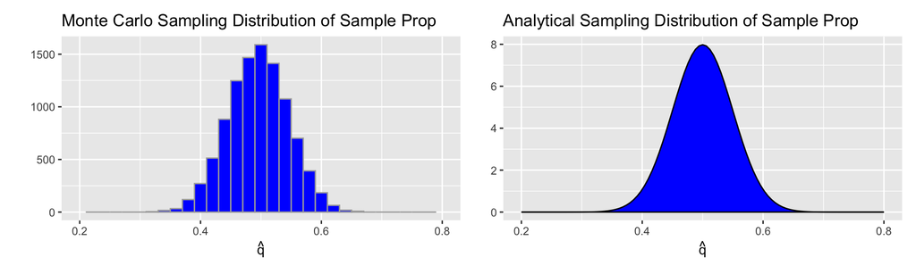

## Sampling Distribution: Analytical

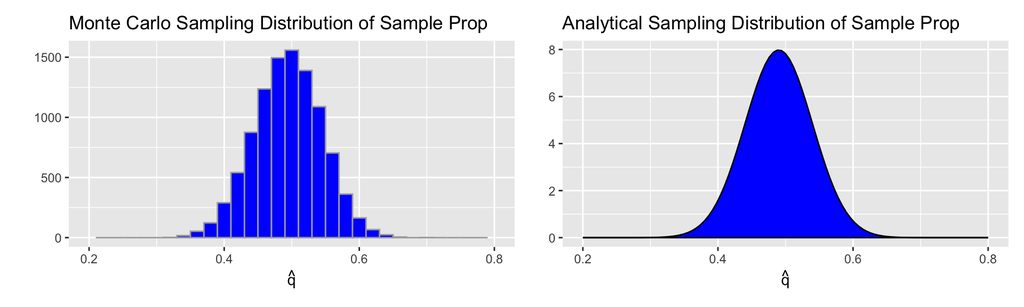

Now it’s easy to calculate the **point estimate**, and any **interval estimate we want!**

```r
q <- mean(coin_flips)
n <- 100 # sample_size

# middle 90% of estimates
qnorm(c(0.05,0.95), mean = q,
      sd = sqrt((q*(1-q))/n))
```

```
[1] 0.4169164 0.5814016
```

## Preview:

What can we do with these point estimates + uncertainty?

- use them to **estimate** the values of our **parameters** $\theta$
  - my mean crossword time is 25.02 minutes 90% interval: [22.2-28.2]
- use them to **make decisions**
  - my mean crossword time is lower than 28 minutes